# Reproducible Research: Peer Assessment 1

## Loading and preprocessing the data

First, we load the activity monitoring dataset using `read.csv()`. Then, we convert the date variable to Date format and examine the structure of the dataset.

```r
# Load the activity monitoring data
activity <- read.csv("activity.csv")

# Convert date to Date format
activity$date <- as.Date(activity$date)

# Examine the structure of the dataset
str(activity)
```

```
## 'data.frame':    17568 obs. of  3 variables:
##  $ steps   : int  NA NA NA NA NA NA NA NA NA NA ...
##  $ date    : Date, format: "2012-10-01" "2012-10-01" ...
##  $ interval: int  0 5 10 15 20 25 30 35 40 45 ...
```

```r
# Display the first six rows
head(activity)
```

```
##   steps       date interval
## 1    NA 2012-10-01        0
## 2    NA 2012-10-01        5
## 3    NA 2012-10-01       10
## 4    NA 2012-10-01       15
## 5    NA 2012-10-01       20
## 6    NA 2012-10-01       25
```

```r
# Display the dimensions of the dataset
dim(activity)
```

```
## [1] 17568     3
```

## What is mean total number of steps taken per day?

First, we calculate the total number of steps taken each day. Missing values are excluded from this calculation.

```r
# Calculate total steps per day, excluding missing observations
daily_steps <- aggregate(
  steps ~ date,
  data = activity,
  FUN = sum,
  na.rm = TRUE
)

# Display daily totals
head(daily_steps)
```

```
##         date steps
## 1 2012-10-02   126
## 2 2012-10-03 11352
## 3 2012-10-04 12116
## 4 2012-10-05 13294
## 5 2012-10-06 15420
## 6 2012-10-07 11015
```

Next, we create a histogram of the total number of steps taken each day.

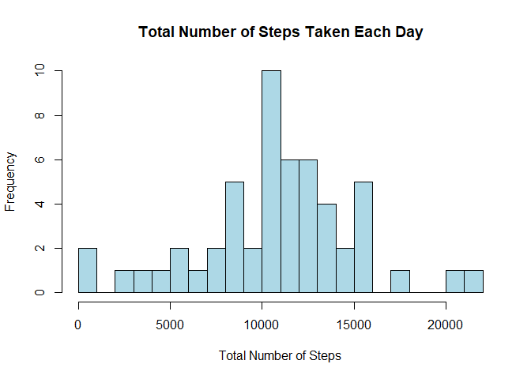

```r
# Create a histogram of daily total steps
hist(
  daily_steps$steps,
  breaks = 20,
  main = "Total Number of Steps Taken Each Day",
  xlab = "Total Number of Steps",
  col = "lightblue",
  border = "black"
)
```

Finally, we calculate the mean and median of the total number of steps taken per day.

```r
# Calculate mean and median daily steps
mean_steps <- mean(daily_steps$steps)
median_steps <- median(daily_steps$steps)

# Display mean and median
mean_steps
```

```
## [1] 10766.19
```

```r
median_steps
```

```
## [1] 10765
```

The mean total number of steps taken per day is 10766.19 and the median is 10765.

## What is the average daily activity pattern?

We calculate the average number of steps for each 5-minute interval, averaged across all days.

```r
# Calculate average steps for each 5-minute interval
interval_steps <- aggregate(
  steps ~ interval,
  data = activity,
  FUN = mean,
  na.rm = TRUE
)

# Display the first six rows
head(interval_steps)
```

```
##   interval     steps
## 1        0 1.7169811
## 2        5 0.3396226
## 3       10 0.1320755
## 4       15 0.1509434
## 5       20 0.0754717
## 6       25 2.0943396
```

We create a time series plot showing the average number of steps taken across all days for each interval.

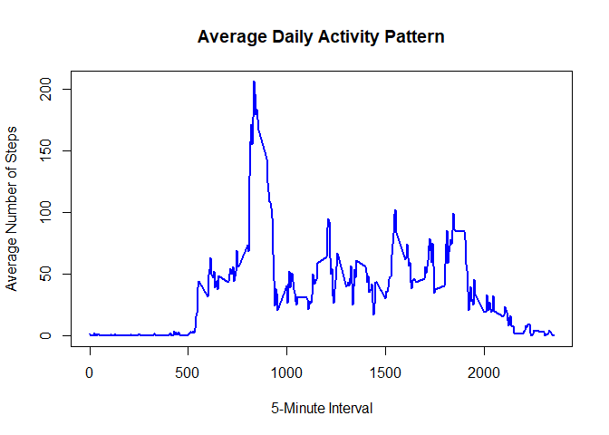

```r
# Plot average steps by 5-minute interval
plot(
  interval_steps$interval,
  interval_steps$steps,
  type = "l",
  main = "Average Daily Activity Pattern",
  xlab = "5-Minute Interval",
  ylab = "Average Number of Steps",
  col = "blue",
  lwd = 2
)
```

We identify the 5-minute interval with the maximum average number of steps.

```r
# Find the interval with the maximum average number of steps
max_interval <- interval_steps[
  which.max(interval_steps$steps),
]

max_interval
```

```
##     interval    steps
## 104      835 206.1698
```

The 5-minute interval with the maximum average number of steps is 835, with an average of 206.17 steps.

## Imputing missing values

First, we calculate the total number of missing values in the dataset.

```r
# Count missing values in the steps variable
missing_values <- sum(is.na(activity$steps))

missing_values
```

```
## [1] 2304
```

There are 2304 missing values in the dataset.

To deal with missing data, we use the average number of steps for each 5-minute interval across all available days. Each missing observation is replaced with the corresponding interval average.

This strategy preserves the typical activity pattern throughout the day.

```r
# Create a copy of the original dataset
activity_imputed <- activity

# Calculate average steps for each interval
interval_means <- aggregate(
  steps ~ interval,
  data = activity,
  FUN = mean,
  na.rm = TRUE
)

# Identify missing observations
missing_index <- is.na(activity_imputed$steps)

# Replace missing values with the corresponding interval mean
activity_imputed$steps[missing_index] <-
  interval_means$steps[
    match(
      activity_imputed$interval[missing_index],
      interval_means$interval
    )
  ]

# Verify that there are no missing values remaining
sum(is.na(activity_imputed$steps))
```

```
## [1] 0
```

Now, we calculate the total number of steps taken each day using the imputed dataset.

```r
# Calculate daily total steps after imputation
daily_steps_imputed <- aggregate(
  steps ~ date,
  data = activity_imputed,
  FUN = sum
)

# Display daily totals
head(daily_steps_imputed)
```

```
##         date    steps
## 1 2012-10-01 10766.19
## 2 2012-10-02   126.00
## 3 2012-10-03 11352.00
## 4 2012-10-04 12116.00
## 5 2012-10-05 13294.00
## 6 2012-10-06 15420.00
```

We create a histogram of the total number of steps taken each day after imputing missing values.

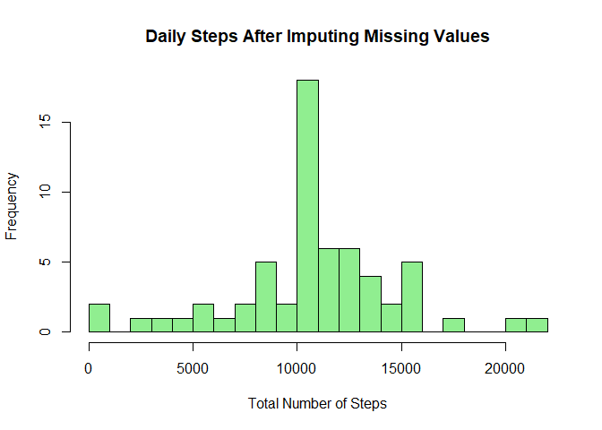

```r
# Create histogram after imputation
hist(
  daily_steps_imputed$steps,
  breaks = 20,
  main = "Daily Steps After Imputing Missing Values",
  xlab = "Total Number of Steps",
  col = "lightgreen",
  border = "black"
)
```

Next, we calculate the mean and median after imputation.

```r
# Calculate mean and median after imputation
mean_steps_imputed <- mean(daily_steps_imputed$steps)
median_steps_imputed <- median(daily_steps_imputed$steps)

mean_steps_imputed
```

```
## [1] 10766.19
```

```r
median_steps_imputed
```

```
## [1] 10766.19
```

The mean total number of steps per day after imputation is 10766.19 and the median is 10766.19.

We compare these results with the estimates obtained before imputation.

```r
# Compare results before and after imputation
comparison <- data.frame(
  Statistic = c("Mean", "Median"),
  Before_Imputation = c(mean_steps, median_steps),
  After_Imputation = c(mean_steps_imputed, median_steps_imputed)
)

comparison
```

```
##   Statistic Before_Imputation After_Imputation
## 1      Mean          10766.19         10766.19
## 2    Median          10765.00         10766.19
```

The mean remains unchanged after imputation, while the median increases slightly. This happens because the missing observations are replaced with the average number of steps for their corresponding 5-minute intervals.

Imputing missing values increases the number of observations available for the analysis and provides a more complete estimate of daily activity. However, the imputed values are estimates rather than actual recorded measurements.

## Are there differences in activity patterns between weekdays and weekends?

First, we create a new factor variable called `day_type` to identify whether each observation corresponds to a weekday or a weekend.

```r
# Create a weekday/weekend variable
activity_imputed$day_type <- factor(
  ifelse(
    as.POSIXlt(activity_imputed$date)$wday %in% c(0, 6),
    "weekend",
    "weekday"
  ),
  levels = c("weekday", "weekend")
)

# Examine the new variable
table(activity_imputed$day_type)
```

```
##
## weekday weekend
##   12960    4608
```

Next, we calculate the average number of steps for each 5-minute interval separately for weekdays and weekends.

```r
# Calculate average steps by interval and day type
activity_pattern <- aggregate(
  steps ~ interval + day_type,
  data = activity_imputed,
  FUN = mean
)

# Examine the resulting dataset
head(activity_pattern)
```

```
##   interval day_type      steps
## 1        0  weekday 2.25115304
## 2        5  weekday 0.44528302
## 3       10  weekday 0.17316562
## 4       15  weekday 0.19790356
## 5       20  weekday 0.09895178
## 6       25  weekday 1.59035639
```

Finally, we create a panel plot comparing the average daily activity patterns between weekdays and weekends.

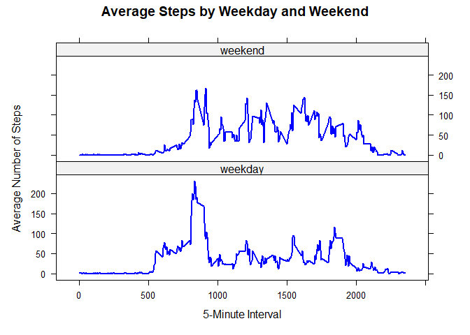

```r
# Load lattice package
library(lattice)

# Create panel plot
xyplot(
  steps ~ interval | day_type,
  data = activity_pattern,
  type = "l",
  layout = c(1, 2),
  main = "Average Steps by Weekday and Weekend",
  xlab = "5-Minute Interval",
  ylab = "Average Number of Steps",
  col = "blue",
  lwd = 2
)
```

The panel plot allows us to compare activity patterns between weekdays and weekends.

The weekday activity pattern shows a pronounced peak during the morning, suggesting a more structured daily routine. Weekend activity is distributed differently throughout the day, with activity levels varying across different intervals. This suggests that physical activity patterns change depending on the day of the week.